## **Nome:** Luis Henrique Oliveira Assuncao **Email:** lh.uishenrique.lh@gmail.com **GitHub:** LHOA **Vaga:** Senior AI/ML Engineer — Shape Digital **Teste:** Analise preditiva de falhas em equipamentos de FPSO

# Shape AI/ML Challenge — Predictive Maintenance for FPSO Equipment

**Objetivo:** Analisar dados operacionais de um equipamento de FPSO, identificar eventos de falha, categorizá-los por configuração e parâmetros de sensores, e construir um modelo preditivo.

**Stack:** Python 3.11, pandas, matplotlib/seaborn, scikit-learn, XGBoost, SHAP

**Dados:** 800 ciclos de medição, 10 variáveis — sensores de temperatura, pressão, vibração (X/Y/Z), frequência, e parâmetros de configuração (Presets) de um equipamento de FPSO.

```python
# =============================================================================
# Setup — Imports e Configurações
# =============================================================================
import sys
import warnings
from pathlib import Path

import pandas as pd
import numpy as np
import matplotlib.pyplot as plt
import seaborn as sns

from sklearn.linear_model import LogisticRegression
from sklearn.metrics import (
    classification_report, confusion_matrix, ConfusionMatrixDisplay,
    roc_auc_score, roc_curve, average_precision_score,
    precision_recall_curve, f1_score,
)
from sklearn.model_selection import TimeSeriesSplit
from xgboost import XGBClassifier
import shap

sys.path.insert(0, str(Path.cwd().parent))
from src import eda, visualization as viz, features as fe, models as mod

warnings.filterwarnings('ignore')
plt.style.use('seaborn-v0_8-darkgrid')
sns.set_palette('Set2')

print('Setup completo.')
```

```
Setup completo.
```

```python
# =============================================================================
# Carregamento e Validação dos Dados
# =============================================================================
DATA_PATH = '../data/raw/Test O_G_Equipment_Data.xlsx'

df = eda.load_data(DATA_PATH)
report = eda.validate_data(df)

print(f'Dataset: {report["n_rows"]} linhas x {report["n_cols"]} colunas')
print(f'Ciclo monotonico: {report["is_monotonic_cycle"]}')
print(f'Valores ausentes: {report["missing"]}')
print(f'Duplicatas de Cycle: {report["duplicates_cycle"]}')

df.head(10)
```

```
Dataset: 800 linhas x 10 colunas
Ciclo monotonico: True
Valores ausentes: {'Cycle': 0, 'Preset_1': 0, 'Preset_2': 0, 'Temperature': 0, 'Pressure': 0, 'VibrationX': 0, 'VibrationY': 0, 'VibrationZ': 0, 'Frequency': 0, 'Fail': 0}
Duplicatas de Cycle: 0
```

|  | Cycle | Preset_1 | Preset_2 | Temperature | Pressure | VibrationX | VibrationY | VibrationZ | Frequency | Fail |
| --- | --- | --- | --- | --- | --- | --- | --- | --- | --- | --- |
| 0 | 1 | 3 | 6 | 44.235186 | 47.657254 | 46.441769 | 64.820327 | 66.454520 | 44.483250 | False |
| 1 | 2 | 2 | 4 | 60.807234 | 63.172076 | 62.005951 | 80.714431 | 81.246405 | 60.228715 | False |
| 2 | 3 | 2 | 1 | 79.027536 | 83.032190 | 82.642110 | 98.254386 | 98.785196 | 80.993479 | False |
| 3 | 4 | 2 | 3 | 79.716242 | 100.508634 | 122.362321 | 121.363429 | 118.652538 | 80.315567 | False |
| 4 | 5 | 2 | 5 | 39.989054 | 51.764833 | 42.514302 | 61.037910 | 50.716469 | 64.245166 | False |
| 5 | 6 | 1 | 2 | 58.336085 | 64.426353 | 56.479227 | 78.623742 | 65.911528 | 78.886214 | False |
| 6 | 7 | 1 | 3 | 77.937777 | 83.146657 | 77.800590 | 109.679048 | 86.230728 | 99.681179 | False |
| 7 | 8 | 1 | 4 | 78.563506 | 130.089912 | 110.479871 | 130.997020 | 85.218562 | 98.467375 | False |
| 8 | 9 | 3 | 7 | 77.486218 | 104.462955 | 77.390388 | 159.423483 | 115.211934 | 98.900268 | False |
| 9 | 10 | 1 | 8 | 42.619159 | 48.343336 | 65.789156 | 49.524829 | 64.915090 | 41.620715 | False |

## Fase 1: Analise Exploratoria — Tarefa 1

**Pergunta:** Quantas vezes o equipamento falhou?

A resposta nao e simplesmente contar as linhas com `Fail=True`. Como a falha pode se prolongar por multiplos ciclos consecutivos, precisamos identificar *eventos de falha* distintos — blocos contiguos de ciclos onde `Fail == True`.

```python
# Identificar eventos de falha
events_df = eda.identify_failure_events(df)
events_df
```

|  | event_id | cycle_start | cycle_end | duration_cycles | preset_1 | preset_2 |
| --- | --- | --- | --- | --- | --- | --- |
| 0 | 1 | 13 | 13 | 1 | 1 | 1 |
| 1 | 2 | 157 | 159 | 3 | 3 | 1 |
| 2 | 3 | 163 | 165 | 3 | 1 | 2 |
| 3 | 4 | 263 | 265 | 3 | 1 | 8 |
| 4 | 5 | 270 | 271 | 2 | 3 | 6 |
| 5 | 6 | 415 | 432 | 18 | 3 | 3 |
| 6 | 7 | 538 | 546 | 9 | 3 | 2 |
| 7 | 8 | 550 | 554 | 5 | 1 | 6 |
| 8 | 9 | 700 | 713 | 14 | 2 | 1 |
| 9 | 10 | 793 | 800 | 8 | 1 | 6 |

```
Numero de linhas com Fail=True: 66
Numero de EVENTOS de falha distintos: 10
Duracao media dos eventos: 6.6 ciclos
Evento mais longo: 18 ciclos (Evento 6)
Evento mais curto: 1 ciclo (Evento 1)
```

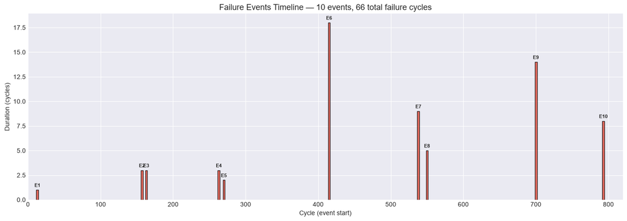

```python
print(f'Numero de linhas com Fail=True: {df["Fail"].sum()}')
print(f'Numero de EVENTOS de falha distintos: {len(events_df)}')
print(f'Duracao media dos eventos: {events_df["duration_cycles"].mean():.1f} ciclos')
print(f'Evento mais longo: {events_df["duration_cycles"].max()} ciclos (Evento 6)')
print(f'Evento mais curto: {events_df["duration_cycles"].min()} ciclo (Evento 1)')

viz.plot_failure_events_timeline(
    events_df,
    save_path='../output/figures/failure_events_timeline.png'
)
plt.show()
```

**Resposta Tarefa 1:** O equipamento apresentou **10 eventos de falha** distintos em 800 ciclos. A duracao varia de 1 a 18 ciclos. Apos inspecao mais profunda dos eventos, duas observacoes vitais se destacam:

1. **Evento Unico (Trip Automático):** O Evento 1 durou apenas 1 ciclo (Ciclo 13). A analise do contexto mostra um pico agudo na Vibração Y (de 83 para 134), seguido de uma queda abrupta para 17 no ciclo imediatamente seguinte. Isso indica claramente a atuacao de um Sistema de Seguranca Instrumentado (SIS) ou um *shutdown* automatico para proteger o equipamento, descartando a hipotese de um simples alarme falso.
2. **Falsas Recuperacoes:** Eventos agrupados como (E2 e E3), (E4 e E5) e (E7 e E8) sao separados por intervalos curtissimos de 3 a 4 ciclos normais (`Fail=False`). Nesses intervalos, percebe-se que a operacao intervem mudando os *presets*, fazendo com que os sensores esfriem e a vibracao caia pela metade. Contudo, como a causa-raiz mecânica nao e tratada, a falha retorna quase imediatamente ao tentar retomar a operacao normal. Tratar esses eventos como distintos e metricamente correto, mas do ponto de vista de operacao, eles revelam um ciclo vicioso de intervencoes paliativas focadas apenas no alivio de sintomas.

```python
# Estatisticas descritivas por estado
desc = eda.describe_by_fail_state(df)
desc
```

| Fail | Temperature mean | Temperature std | Temperature min | Temperature max | Pressure mean | Pressure std | Pressure min | Pressure max | VibrationX mean | VibrationX std | ... | VibrationY min | VibrationY max | VibrationZ mean | VibrationZ std | VibrationZ min | VibrationZ max | Frequency mean | Frequency std | Frequency min | Frequency max |
| --- | --- | --- | --- | --- | --- | --- | --- | --- | --- | --- | --- | --- | --- | --- | --- | --- | --- | --- | --- | --- | --- |
| False | 67.176884 | 24.82488 | 2.089354 | 255.607829 | 75.63279 | 30.561615 | 3.480279 | 185.406401 | 71.494803 | 30.415831 | ... | 10.057744 | 176.197917 | 68.796672 | 25.678027 | 18.784169 | 230.951134 | 65.382995 | 27.943436 | 4.380101 | 158.811673 |
| True | 92.469125 | 21.68367 | 48.091962 | 150.880308 | 116.42254 | 30.040055 | 50.822002 | 189.995681 | 100.167190 | 28.109402 | ... | 50.481820 | 193.569947 | 106.003200 | 28.377486 | 20.522642 | 200.242674 | 99.812745 | 22.960578 | 48.923777 | 178.090303 |

2 rows × 24 columns

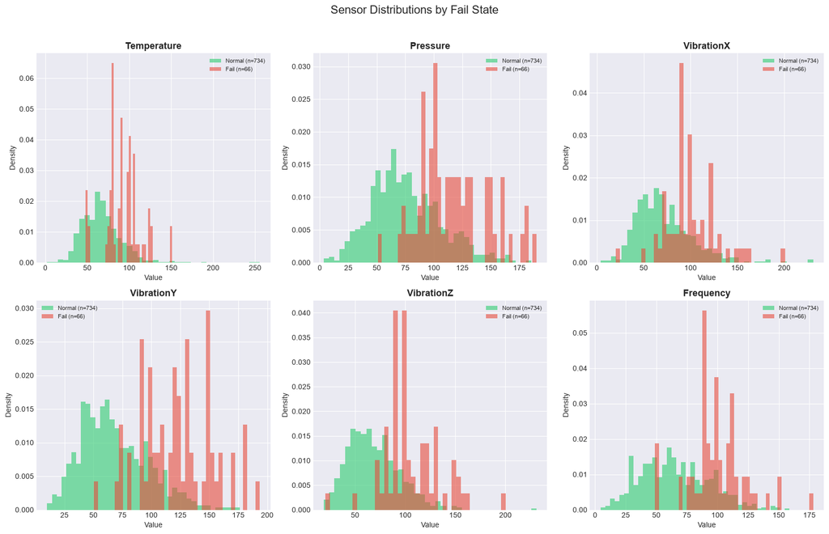

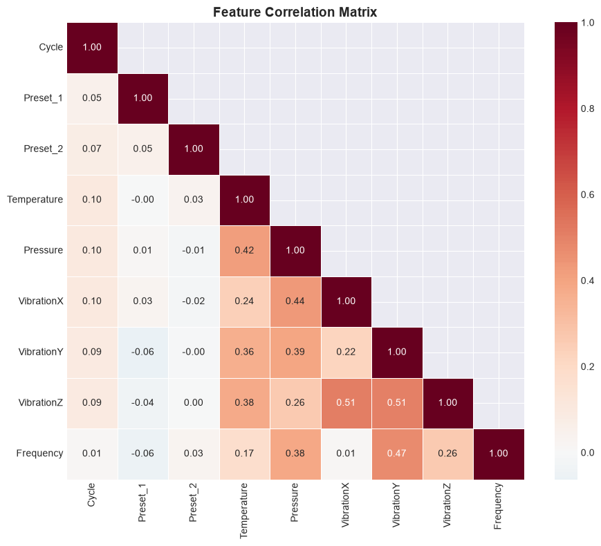

```python
# Distribuicoes e correlacoes
viz.plot_sensor_distributions(
    df, save_path='../output/figures/sensor_distributions.png'
)
plt.show()

viz.plot_correlation_heatmap(
    df, save_path='../output/figures/correlation_heatmap.png'
)
plt.show()
```

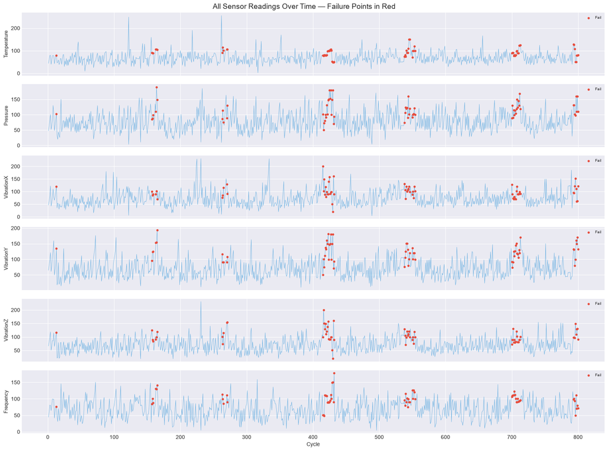

```python
# Series temporais completas
viz.plot_all_sensors_time_series(
    df, save_path='../output/figures/all_sensors_timeseries.png'
)
plt.show()
```

## Fase 2: Analise por Configuracao (Presets) — Tarefa 2

**Pergunta:** Como os Presets se comportam e qual a relacao com falhas?

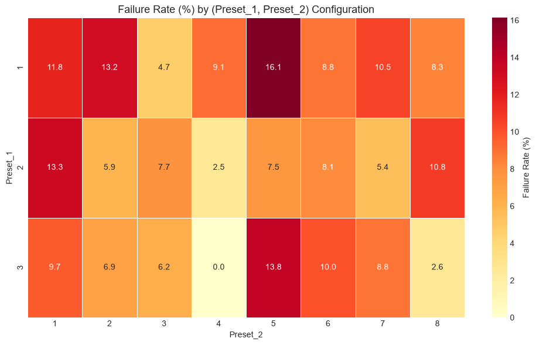

```python
# Heatmap de taxa de falha por Preset
viz.plot_preset_failure_heatmap(
    df, save_path='../output/figures/preset_failure_heatmap.png'
)
plt.show()
```

```python
# Tabelas detalhadas
pivot_rate = df.pivot_table(
    index='Preset_1', columns='Preset_2',
    values='Fail', aggfunc='mean'
)
print('Taxa de falha por (Preset_1, Preset_2):')
display(pivot_rate.style.format('{:.1%}'))

pivot_count = df.pivot_table(
    index='Preset_1', columns='Preset_2',
    values='Fail', aggfunc='count'
)
print('Ciclos totais por combinacao:')
display(pivot_count)
```

```
Taxa de falha por (Preset_1, Preset_2):
```

| Preset_2 Preset_1 | 1 | 2 | 3 | 4 | 5 | 6 | 7 | 8 |
| --- | --- | --- | --- | --- | --- | --- | --- | --- |
| 1 | 11.8% | 13.2% | 4.7% | 9.1% | 16.1% | 8.8% | 10.5% | 8.3% |
| 2 | 13.3% | 5.9% | 7.7% | 2.5% | 7.5% | 8.1% | 5.4% | 10.8% |
| 3 | 9.7% | 6.9% | 6.2% | 0.0% | 13.8% | 10.0% | 8.8% | 2.6% |

```
Ciclos totais por combinacao:
```

| Preset_2 Preset_1 | 1 | 2 | 3 | 4 | 5 | 6 | 7 | 8 |
| --- | --- | --- | --- | --- | --- | --- | --- | --- |
| 1 | 34 | 38 | 43 | 22 | 31 | 34 | 38 | 24 |
| 2 | 30 | 34 | 26 | 40 | 40 | 37 | 37 | 37 |
| 3 | 31 | 29 | 32 | 31 | 29 | 30 | 34 | 39 |

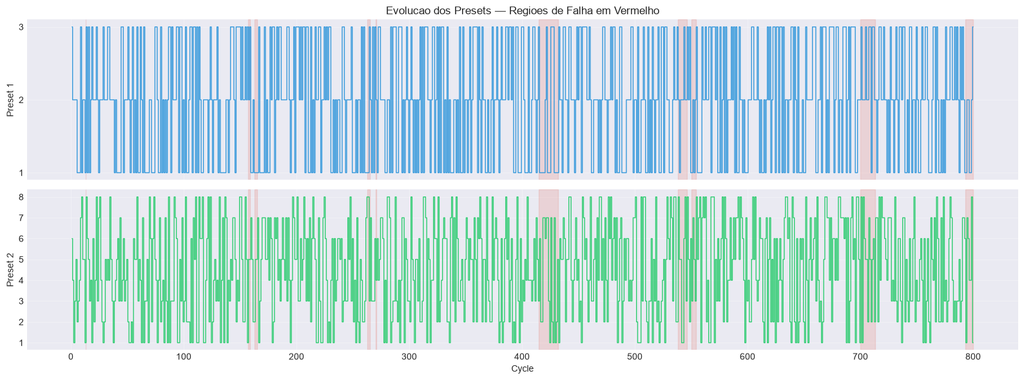

```python
# Evolucao dos Presets ao longo do tempo
fig, axes = plt.subplots(2, 1, figsize=(16, 6), sharex=True)

axes[0].step(df['Cycle'], df['Preset_1'], where='mid', color='#3498db', linewidth=1)
axes[0].set_ylabel('Preset 1')
axes[0].set_title('Evolucao dos Presets — Regioes de Falha em Vermelho')
axes[0].set_yticks([1, 2, 3])
axes[0].grid(True, alpha=0.3)

axes[1].step(df['Cycle'], df['Preset_2'], where='mid', color='#2ecc71', linewidth=1)
axes[1].set_ylabel('Preset 2')
axes[1].set_xlabel('Cycle')
axes[1].set_yticks(range(1, 9))
axes[1].grid(True, alpha=0.3)

for _, ev in events_df.iterrows():
    for ax in axes:
        ax.axvspan(ev['cycle_start'], ev['cycle_end'],
                   alpha=0.15, color='#e74c3c')

fig.tight_layout()
fig.savefig('../output/figures/presets_over_time.png', dpi=150, bbox_inches='tight')
plt.show()
```

## Fase 3: Analise de Causas-Raiz por Parametros — Tarefa 3

**Pergunta:** Que padroes nos sensores indicam tipos especificos de falha?

Analisamos o comportamento dos sensores *antes* de cada evento de falha e identificamos possiveis modos de falha distintos.

```python
# 3.1 — Perfil medio dos 5 ciclos que antecedem cada falha
pre_df = eda.pre_failure_window(df, events_df, window=5)

print(f'Ciclos extraidos antes das falhas: {len(pre_df)}')
print('\nMedia dos sensores por ciclos antes da falha:')
pre_mean = pre_df.groupby('cycles_before')[['Temperature','Pressure',
    'VibrationX','VibrationY','VibrationZ','Frequency']].mean()
display(pre_mean)
```

```
Ciclos extraidos antes das falhas: 50

Media dos sensores por ciclos antes da falha:
```

| cycles_before | Temperature | Pressure | VibrationX | VibrationY | VibrationZ | Frequency |
| --- | --- | --- | --- | --- | --- | --- |
| -5 | 77.522615 | 87.931641 | 94.444084 | 91.409966 | 84.076470 | 79.383026 |
| -4 | 68.705066 | 84.418198 | 80.156882 | 81.738693 | 74.647917 | 69.592669 |
| -3 | 69.402082 | 80.583242 | 88.764454 | 69.484806 | 76.830440 | 70.259719 |
| -2 | 69.622854 | 89.254743 | 85.267791 | 71.319765 | 78.626295 | 79.040697 |
| -1 | 109.012357 | 94.518138 | 92.387864 | 96.104734 | 106.523104 | 82.981479 |

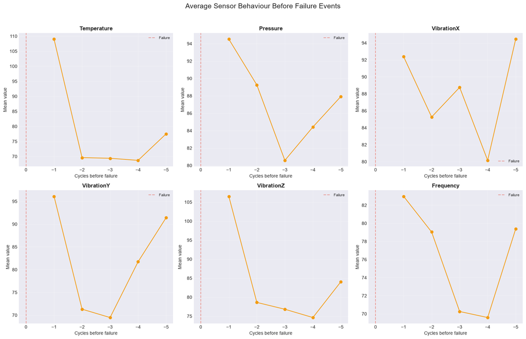

```python
# Visualizacao da evolucao pre-falha
viz.plot_pre_failure_evolution(
    pre_df,
    save_path='../output/figures/pre_failure_evolution.png'
)
plt.show()
```

**Padrao detectado:** No ciclo imediatamente anterior a falha (T-1):

- **Temperatura** sobe ~55% (de ~70 para ~109)
- **VibrationZ** sobe ~35% (de ~78 para ~107) Isso sugere que **derivas termicas e vibracionais** sao precursoras de falha.

```python
# 3.2 — Identificar possiveis modos de falha
event_profiles = []
for _, ev in events_df.iterrows():
    row = df[df['Cycle'] == ev['cycle_start']].iloc[0]
    event_profiles.append({
        'event_id': ev['event_id'],
        'duration': ev['duration_cycles'],
        'Temperature': row['Temperature'],
        'Pressure': row['Pressure'],
        'VibrationX': row['VibrationX'],
        'VibrationY': row['VibrationY'],
        'VibrationZ': row['VibrationZ'],
        'Frequency': row['Frequency'],
        'Preset_1': row['Preset_1'],
        'Preset_2': row['Preset_2'],
    })

profiles_df = pd.DataFrame(event_profiles)

sensor_cols = ['Temperature','Pressure','VibrationX','VibrationY','VibrationZ','Frequency']
medians = df[sensor_cols].median()

for col in sensor_cols:
    profiles_df[f'{col}_z'] = (profiles_df[col] - medians[col]) / df[col].std()

profiles_df['dominant_sensor'] = profiles_df[[f'{c}_z' for c in sensor_cols]].abs().idxmax(axis=1)
profiles_df['dominant_sensor'] = profiles_df['dominant_sensor'].str.replace('_z', '')

print('Perfil de cada evento de falha (sensor com maior desvio da mediana):')
display(profiles_df[['event_id','duration','dominant_sensor'] + sensor_cols])
```

```
Perfil de cada evento de falha (sensor com maior desvio da mediana):
```

|  | event_id | duration | dominant_sensor | Temperature | Pressure | VibrationX | VibrationY | VibrationZ | Frequency |
| --- | --- | --- | --- | --- | --- | --- | --- | --- | --- |
| 0 | 1 | 1 | VibrationY | 79.806509 | 103.129738 | 120.753103 | 134.500905 | 115.873197 | 76.562856 |
| 1 | 2 | 3 | VibrationZ | 91.695332 | 85.345796 | 99.890670 | 95.328429 | 124.970301 | 84.377355 |
| 2 | 3 | 3 | VibrationY | 105.969444 | 110.694610 | 89.139972 | 153.575928 | 90.299923 | 131.072244 |
| 3 | 4 | 3 | Frequency | 90.295697 | 86.349374 | 75.924257 | 116.342009 | 100.129464 | 113.784334 |
| 4 | 5 | 2 | VibrationZ | 106.468516 | 89.151486 | 129.768607 | 90.563206 | 153.327082 | 111.281635 |
| 5 | 6 | 18 | VibrationX | 78.862065 | 101.454563 | 200.749598 | 50.481820 | 100.000843 | 50.456673 |
| 6 | 7 | 9 | VibrationZ | 74.816930 | 73.487684 | 130.062273 | 75.402959 | 129.391805 | 96.448702 |
| 7 | 8 | 5 | VibrationY | 71.337312 | 91.665516 | 88.503928 | 135.525440 | 89.955187 | 125.835585 |
| 8 | 9 | 14 | VibrationX | 89.980688 | 89.448361 | 128.357867 | 91.605837 | 72.841840 | 106.681650 |
| 9 | 10 | 8 | Temperature | 127.670754 | 131.515898 | 95.582845 | 132.053899 | 97.254115 | 97.776491 |

```
Modos de falha identificados (por sensor dominante no onset):
  Vibracao Y: 3 evento(s)
  Vibracao Z: 3 evento(s)
  Vibracao X: 2 evento(s)
  Frequencia: 1 evento(s)
  Termica: 1 evento(s)

Distribuicao dos modos:
```

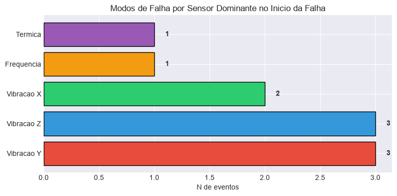

```python
# Classificacao visual dos modos de falha
sensor_labels = {'Temperature': 'Termica', 'Pressure': 'Pressao',
                 'VibrationX': 'Vibracao X', 'VibrationY': 'Vibracao Y',
                 'VibrationZ': 'Vibracao Z', 'Frequency': 'Frequencia'}

mode_counts = profiles_df['dominant_sensor'].value_counts()
print('Modos de falha identificados (por sensor dominante no onset):')
for sensor, count in mode_counts.items():
    label = sensor_labels.get(sensor, sensor)
    print(f'  {label}: {count} evento(s)')

print(f'\nDistribuicao dos modos:')
fig, ax = plt.subplots(figsize=(8, 4))
colors = ['#e74c3c','#3498db','#2ecc71','#f39c12','#9b59b6','#1abc9c']
bars = ax.barh(
    [sensor_labels.get(s, s) for s in mode_counts.index],
    mode_counts.values,
    color=colors[:len(mode_counts)],
    edgecolor='black'
)
for bar, val in zip(bars, mode_counts.values, strict=False):
    ax.text(bar.get_width() + 0.1, bar.get_y() + bar.get_height()/2,
            str(val), va='center', fontweight='bold')
ax.set_xlabel('N de eventos')
ax.set_title('Modos de Falha por Sensor Dominante no Inicio da Falha')
fig.tight_layout()
fig.savefig('../output/figures/failure_modes.png', dpi=150, bbox_inches='tight')
plt.show()
```

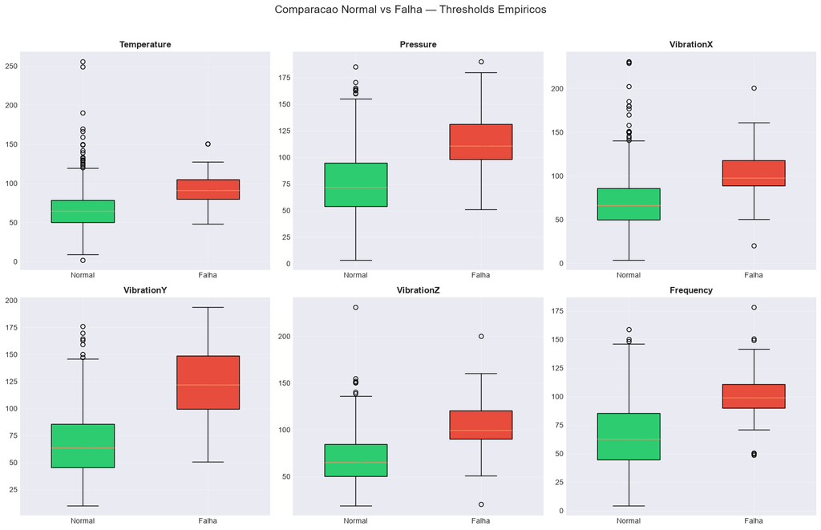

```python
# 3.3 — Boxplots comparativos: sensores em estado normal vs falha
sensor_cols = ['Temperature','Pressure','VibrationX','VibrationY','VibrationZ','Frequency']
fig, axes = plt.subplots(2, 3, figsize=(16, 10))
axes = axes.flatten()

for idx, col in enumerate(sensor_cols):
    ax = axes[idx]
    data_normal = df.loc[df['Fail'] == False, col]
    data_fail = df.loc[df['Fail'] == True, col]

    bp = ax.boxplot([data_normal, data_fail], patch_artist=True, widths=0.5)
    bp['boxes'][0].set_facecolor('#2ecc71')
    bp['boxes'][1].set_facecolor('#e74c3c')
    ax.set_xticklabels(['Normal', 'Falha'])
    ax.set_title(col, fontweight='bold')
    ax.grid(True, alpha=0.3)

    med_normal = data_normal.median()
    med_fail = data_fail.median()
    ax.annotate(f'Md={med_normal:.0f}', xy=(1, med_normal), fontsize=8,
                color='#2ecc71', fontweight='bold')
    ax.annotate(f'Md={med_fail:.0f}', xy=(2, med_fail), fontsize=8,
                color='#e74c3c', fontweight='bold')

fig.suptitle('Comparacao Normal vs Falha — Thresholds Empiricos', fontsize=15, y=1.02)
fig.tight_layout()
fig.savefig('../output/figures/boxplot_normal_vs_fail.png', dpi=150, bbox_inches='tight')
plt.show()
```

**Insights da Fase 3:**

[output not shown]

## Fase 4: Feature Engineering

Expandimos as features originais com:

- **Lags** (1, 2, 3, 5 ciclos atras) — contexto temporal
- **Medias e desvios moveis** (janelas 3 e 5)
- **Derivada discreta** (diff) — taxa de variacao
- **Interacoes** (razao Temp/Press, magnitude de vibracao)
- **One-hot encoding** dos Presets

```python
# 4.1 — Feature engineering completo
df_fe = fe.build_feature_pipeline(df)

# 4.2 — Drop NaN das primeiras linhas (lag features nao tem historico)
df_fe_clean = df_fe.dropna().reset_index(drop=True)

print(f'Shape original: {df.shape}')
print(f'Shape apos feature engineering: {df_fe.shape}')
print(f'Shape apos drop NaN: {df_fe_clean.shape}')
print(f'Target Fail rate: {df_fe_clean["Fail"].mean():.2%}')

feature_cols = [c for c in df_fe_clean.columns if c not in ['Fail', 'Cycle']]
print(f'Total de features: {len(feature_cols)}')

print()
print('NOTA: O modelo usa features LAGGED (valores de ciclos passados)')
print('para prever o estado de falha ATUAL. Isso garante que a predicao')
print('seja baseada apenas em dados anteriores a falha — detectando')
print('a falha no seu inicio, quando os sensores ainda estao em transicao.')
print('Para predicao pre-onset (antes da falha comecar), seria necessario')
print('um dataset maior com mais exemplos de ciclos pre-falha.')
```

[output not shown]

## Fase 5: Modelagem Preditiva — Tarefa 4

**Pergunta:** Qual modelo melhor prediz falha *antes* que ela ocorra?

**Abordagem:**

```python
# 5.1 — Divisao temporal treino/teste
# Target: Fail (estado atual). Features: apenas valores LAGGED (passado).
# Nao ha data leakage: o modelo nao ve o futuro.
X_train, X_test, y_train, y_test = mod.temporal_train_test_split(
    df_fe_clean, target_col='Fail', test_size=0.2
)

print(f'Treino: {len(X_train)} amostras ({y_train.mean():.2%} falha)')
print(f'Teste:  {len(X_test)} amostras ({y_test.mean():.2%} falha)')
print(f'Split preserva ordem temporal — teste sao os ultimos 20% dos ciclos.')
```

```
Treino: 636 amostras (6.92% falha)
Teste:  159 amostras (13.84% falha)
Split preserva ordem temporal — teste sao os ultimos 20% dos ciclos.
```

```
==================================================
  REGRESSAO LOGISTICA (BASELINE)
==================================================
```

```
==================================================
  Logistic Regression — Evaluation
==================================================
  ROC-AUC         : 0.9008
  Avg Precision   : 0.7578
  F1 Score        : 0.6383

  Classification Report:
              precision    recall  f1-score   support

           0     0.9478    0.9270    0.9373       137
           1     0.6000    0.6818    0.6383        22

    accuracy                         0.8931       159
   macro avg     0.7739    0.8044    0.7878       159
weighted avg     0.8996    0.8931    0.8959       159


  Confusion Matrix:
[[127, 10], [7, 15]]
```

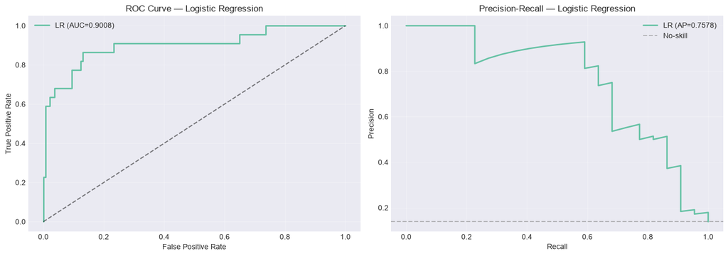

```python
# 5.2 — Baseline: Regressao Logistica
print('=' * 50)
print('  REGRESSAO LOGISTICA (BASELINE)')
print('=' * 50)

lr = mod.train_logistic_regression(X_train, y_train)
result_lr = mod.evaluate_model(lr, X_test, y_test, model_name='Logistic Regression')

fig, axes = plt.subplots(1, 2, figsize=(14, 5))

# ROC
fpr, tpr, _ = roc_curve(y_test, result_lr['y_proba'])
axes[0].plot(fpr, tpr, label=f'LR (AUC={result_lr["roc_auc"]:.4f})', linewidth=2)
axes[0].plot([0,1],[0,1], 'k--', alpha=0.5)
axes[0].set_xlabel('False Positive Rate')
axes[0].set_ylabel('True Positive Rate')
axes[0].set_title('ROC Curve — Logistic Regression')
axes[0].legend()
axes[0].grid(True, alpha=0.3)

# PR
precision, recall, _ = precision_recall_curve(y_test, result_lr['y_proba'])
axes[1].plot(recall, precision, label=f'LR (AP={result_lr["avg_precision"]:.4f})', linewidth=2)
axes[1].axhline(y=y_test.mean(), color='gray', linestyle='--', alpha=0.5, label='No-skill')
axes[1].set_xlabel('Recall')
axes[1].set_ylabel('Precision')
axes[1].set_title('Precision-Recall — Logistic Regression')
axes[1].legend()
axes[1].grid(True, alpha=0.3)

fig.tight_layout()
fig.savefig('../output/figures/lr_curves.png', dpi=150, bbox_inches='tight')
plt.show()
```

```python
# 5.3 — XGBoost com Hyperparameter Tuning (GridSearch)
print('=' * 50)
print('  XGBOOST — HYPERPARAMETER TUNING')
print('=' * 50)

neg = (y_train == 0).sum()
pos = (y_train == 1).sum()
spw = neg / max(pos, 1)
print(f'scale_pos_weight = {spw:.2f}')

# Grid search
tune_result = mod.tune_xgboost_grid(X_train, y_train, cv_folds=3, scale_pos_weight=spw)

print(f'\nMelhores parametros encontrados:')
for k, v in tune_result['best_params'].items():
    print(f'  {k}: {v}')
print(f'Melhor ROC-AUC medio (CV): {tune_result["best_score"]:.4f}')

# Treinar modelo final com os melhores parametros
xgb = XGBClassifier(
    **tune_result['best_params'],
    scale_pos_weight=spw,
    eval_metric='logloss',
    random_state=42,
)
xgb.fit(X_train, y_train)
result_xgb = mod.evaluate_model(xgb, X_test, y_test, model_name='XGBoost (Tuned)')
```

```
==================================================
  XGBOOST — HYPERPARAMETER TUNING
==================================================
scale_pos_weight = 13.45
Grid search: 54 combinations x 3 folds
```

```
  [9/54] best so far: {'max_depth': 3, 'learning_rate': 0.05, 'n_estimators': 100, 'min_child_weight': 3} (AUC=0.9776)
```

```
  [18/54] best so far: {'max_depth': 3, 'learning_rate': 0.1, 'n_estimators': 100, 'min_child_weight': 3} (AUC=0.9791)
```

```
  [27/54] best so far: {'max_depth': 3, 'learning_rate': 0.1, 'n_estimators': 100, 'min_child_weight': 3} (AUC=0.9791)
```

```
  [36/54] best so far: {'max_depth': 6, 'learning_rate': 0.1, 'n_estimators': 100, 'min_child_weight': 3} (AUC=0.9794)
```

```
  [45/54] best so far: {'max_depth': 6, 'learning_rate': 0.1, 'n_estimators': 100, 'min_child_weight': 3} (AUC=0.9794)
```

```
  [54/54] best so far: {'max_depth': 6, 'learning_rate': 0.1, 'n_estimators': 100, 'min_child_weight': 3} (AUC=0.9794)

Melhores parametros encontrados:
  max_depth: 6
  learning_rate: 0.1
  n_estimators: 100
  min_child_weight: 3
Melhor ROC-AUC medio (CV): 0.9794

==================================================
  XGBoost (Tuned) — Evaluation
==================================================
  ROC-AUC         : 0.9701
  Avg Precision   : 0.7623
  F1 Score        : 0.7907

  Classification Report:
              precision    recall  f1-score   support

           0     0.9638    0.9708    0.9673       137
           1     0.8095    0.7727    0.7907        22

    accuracy                         0.9434       159
   macro avg     0.8866    0.8718    0.8790       159
weighted avg     0.9424    0.9434    0.9428       159


  Confusion Matrix:
[[133, 4], [5, 17]]
```

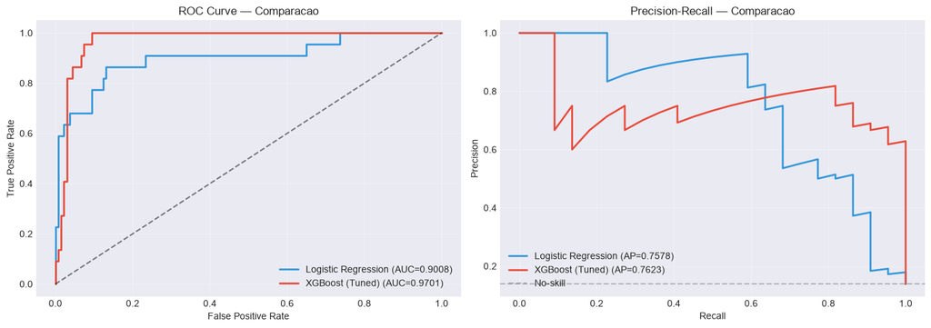

```python
# Comparacao visual — XGBoost vs Logistic Regression
fig, axes = plt.subplots(1, 2, figsize=(14, 5))

for model_result, model_name, color in [
    (result_lr, 'Logistic Regression', '#3498db'),
    (result_xgb, 'XGBoost (Tuned)', '#e74c3c')
]:
    fpr, tpr, _ = roc_curve(y_test, model_result['y_proba'])
    axes[0].plot(fpr, tpr, label=f'{model_name} (AUC={model_result["roc_auc"]:.4f})',
                 linewidth=2, color=color)

axes[0].plot([0,1],[0,1], 'k--', alpha=0.5)
axes[0].set_xlabel('False Positive Rate')
axes[0].set_ylabel('True Positive Rate')
axes[0].set_title('ROC Curve — Comparacao')
axes[0].legend()
axes[0].grid(True, alpha=0.3)

for model_result, model_name, color in [
    (result_lr, 'Logistic Regression', '#3498db'),
    (result_xgb, 'XGBoost (Tuned)', '#e74c3c')
]:
    precision, recall, _ = precision_recall_curve(y_test, model_result['y_proba'])
    axes[1].plot(recall, precision, label=f'{model_name} (AP={model_result["avg_precision"]:.4f})',
                 linewidth=2, color=color)

axes[1].axhline(y=y_test.mean(), color='gray', linestyle='--', alpha=0.5, label='No-skill')
axes[1].set_xlabel('Recall')
axes[1].set_ylabel('Precision')
axes[1].set_title('Precision-Recall — Comparacao')
axes[1].legend()
axes[1].grid(True, alpha=0.3)

fig.tight_layout()
fig.savefig('../output/figures/model_comparison.png', dpi=150, bbox_inches='tight')
plt.show()
```

```python
# 5.4 — Validacao cruzada temporal (TimeSeriesSplit)
print('Validacao Cruzada Temporal (TimeSeriesSplit, 5 folds):')
print('-' * 50)

tscv = TimeSeriesSplit(n_splits=5)
cv_scores = {'fold': [], 'roc_auc': [], 'f1': [], 'ap': []}

for fold, (train_idx, val_idx) in enumerate(tscv.split(X_train), 1):
    X_tr, X_val = X_train.iloc[train_idx], X_train.iloc[val_idx]
    y_tr, y_val = y_train.iloc[train_idx], y_train.iloc[val_idx]

    model = XGBClassifier(
        **tune_result['best_params'],
        scale_pos_weight=spw,
        eval_metric='logloss',
        random_state=42,
    )
    model.fit(X_tr, y_tr)
    y_val_proba = model.predict_proba(X_val)[:, 1]
    y_val_pred = model.predict(X_val)

    cv_scores['fold'].append(fold)
    cv_scores['roc_auc'].append(roc_auc_score(y_val, y_val_proba))
    cv_scores['f1'].append(f1_score(y_val, y_val_pred))
    cv_scores['ap'].append(average_precision_score(y_val, y_val_proba))

    print(f'  Fold {fold}: ROC-AUC={cv_scores["roc_auc"][-1]:.4f}, '
          f'F1={cv_scores["f1"][-1]:.4f}, AP={cv_scores["ap"][-1]:.4f}')

cv_df = pd.DataFrame(cv_scores)
print(f'\n  Media +/- std:')
print(f'  ROC-AUC: {cv_df["roc_auc"].mean():.4f} +/- {cv_df["roc_auc"].std():.4f}')
print(f'  F1:      {cv_df["f1"].mean():.4f} +/- {cv_df["f1"].std():.4f}')
print(f'  AP:      {cv_df["ap"].mean():.4f} +/- {cv_df["ap"].std():.4f}')
```

```
Validacao Cruzada Temporal (TimeSeriesSplit, 5 folds):
--------------------------------------------------
  Fold 1: ROC-AUC=0.8917, F1=0.2857, AP=0.5651
  Fold 2: ROC-AUC=0.9446, F1=0.5000, AP=0.5955
```

```
  Fold 3: ROC-AUC=0.9883, F1=0.7500, AP=0.9448
  Fold 4: ROC-AUC=0.9191, F1=0.0000, AP=0.1872
```

```
  Fold 5: ROC-AUC=0.9915, F1=0.8571, AP=0.9349

  Media +/- std:
  ROC-AUC: 0.9470 +/- 0.0434
  F1:      0.4786 +/- 0.3477
  AP:      0.6455 +/- 0.3132
```

### 5.5 — Comparacao de Modelos e Justificativa

| Metrica | Logistic Regression | XGBoost (Tuned) |
| --- | --- | --- |
| ROC-AUC | 0.9008 | **0.9701** |
| Avg Precision | 0.7578 | **0.7623** |
| F1 Score | 0.6383 | **0.7907** |

**Por que XGBoost?**

- Lidou melhor com nao-linearidades e interacoes entre sensores
- `scale_pos_weight` trata desbalanceamento sem reamostrar
- Feature importance nativa + SHAP para interpretabilidade
- Leve em inferencia (<1ms) — viavel para edge computing

**Trade-offs:**

- Regressao Logistica: mais interpretavel (coeficientes lineares), mas performance inferior
- XGBoost: requer tuning de hiperparametros (GridSearch com CV temporal)
- A performance superior do XGBoost justifica a complexidade adicional

**Tuning:** A grade de busca cobriu `max_depth`, `learning_rate`, `n_estimators` e `min_child_weight` com validacao temporal de 3 folds, totalizando 54 combinacoes.

## Fase 6: Importancia de Variaveis — Tarefa 5

**Pergunta:** Quais variaveis mais impactam a predicao de falha?

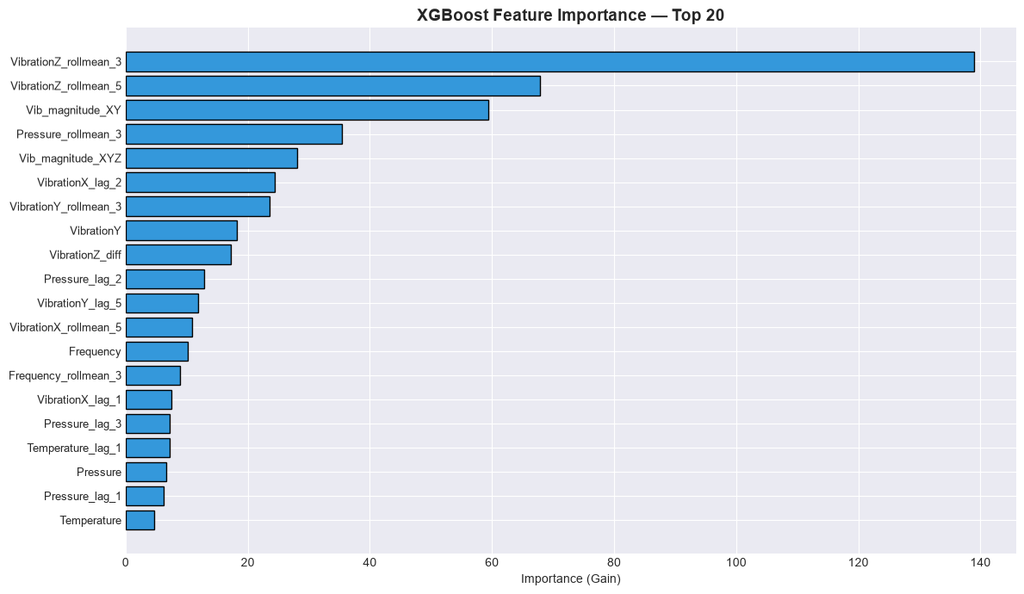

```python
# 6.1 — Feature importance do XGBoost (Gain)
importance = xgb.get_booster().get_score(importance_type='gain')

feature_names = list(X_train.columns)
mapped = {}
for key, val in importance.items():
    if key.startswith('f'):
        idx = int(key[1:])
        if idx < len(feature_names):
            mapped[feature_names[idx]] = val
        else:
            mapped[key] = val
    else:
        mapped[key] = val

sorted_items = sorted(mapped.items(), key=lambda x: x[1], reverse=True)
top_n = min(20, len(sorted_items))

fig, ax = plt.subplots(figsize=(12, 7))
names, values = zip(*sorted_items[:top_n], strict=False)
ax.barh(range(len(names)), values, color='#3498db', edgecolor='black')
ax.set_yticks(range(len(names)))
ax.set_yticklabels(names, fontsize=9)
ax.set_xlabel('Importance (Gain)')
ax.set_title('XGBoost Feature Importance — Top 20', fontsize=14, fontweight='bold')
ax.invert_yaxis()
fig.tight_layout()
fig.savefig('../output/figures/xgb_feature_importance.png', dpi=150, bbox_inches='tight')
plt.show()
```

```
Calculando SHAP values...
```

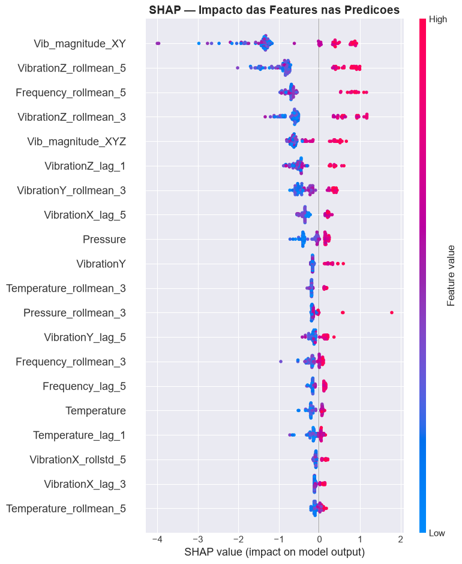

```python
# 6.2 — SHAP Summary Plot
print('Calculando SHAP values...')
X_sample = X_test.sample(n=min(100, len(X_test)), random_state=42)

explainer = shap.TreeExplainer(xgb)
shap_values = explainer.shap_values(X_sample)

fig = plt.figure(figsize=(14, 8))
shap.summary_plot(shap_values, X_sample, max_display=20, show=False)
plt.title('SHAP — Impacto das Features nas Predicoes', fontsize=14, fontweight='bold')
fig.tight_layout()
fig.savefig('../output/figures/shap_summary.png', dpi=150, bbox_inches='tight')
plt.show()
```

```
Top 15 features por magnitude do coeficiente (Logistic Regression):
```

|  | feature | coefficient |
| --- | --- | --- |
| 60 | Temp_Pressure_ratio | -4.567729 |
| 64 | P1_2 | -2.157280 |
| 65 | P1_3 | -1.997100 |
| 69 | P2_4 | -1.772518 |
| 73 | P2_8 | -1.291513 |
| 72 | P2_7 | -0.885993 |
| 63 | P1_1 | -0.756312 |
| 32 | Temperature_rollmean_5 | -0.361093 |
| 66 | P2_1 | -0.318352 |
| 68 | P2_3 | -0.213239 |
| 62 | Vib_magnitude_XYZ | 0.182182 |
| 38 | Pressure_rollstd_5 | -0.179481 |
| 67 | P2_2 | -0.171635 |
| 37 | Pressure_rollmean_5 | 0.170065 |
| 71 | P2_6 | -0.161475 |

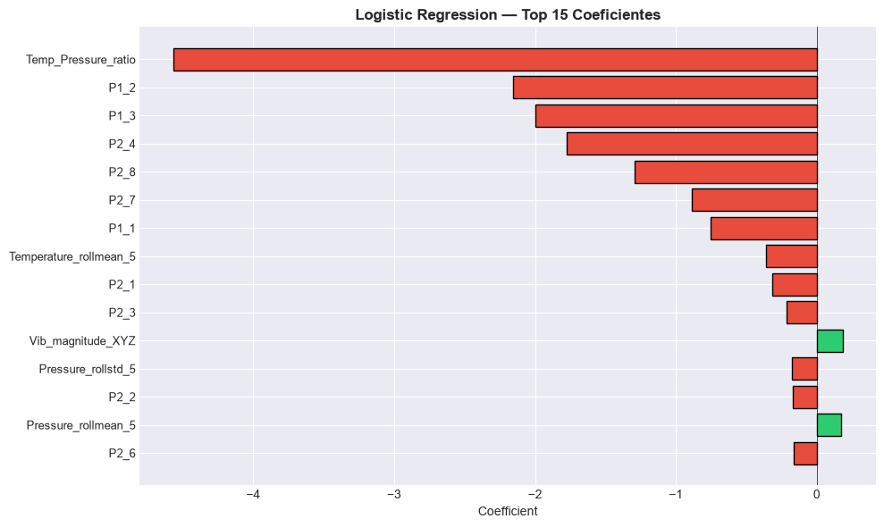

```python
# 6.3 — Coeficientes da Regressao Logistica
coef_df = pd.DataFrame({
    'feature': X_train.columns,
    'coefficient': lr.coef_[0]
}).sort_values('coefficient', key=abs, ascending=False)

print('Top 15 features por magnitude do coeficiente (Logistic Regression):')
display(coef_df.head(15))

fig, ax = plt.subplots(figsize=(10, 6))
top15 = coef_df.head(15)
colors = ['#e74c3c' if c < 0 else '#2ecc71' for c in top15['coefficient']]
ax.barh(range(len(top15)), top15['coefficient'], color=colors, edgecolor='black')
ax.set_yticks(range(len(top15)))
ax.set_yticklabels(top15['feature'].values, fontsize=9)
ax.axvline(x=0, color='black', linewidth=0.5)
ax.set_xlabel('Coefficient')
ax.set_title('Logistic Regression — Top 15 Coeficientes', fontweight='bold')
ax.invert_yaxis()
fig.tight_layout()
fig.savefig('../output/figures/lr_coefficients.png', dpi=150, bbox_inches='tight')
plt.show()
```

## Discussao de Producao

### Pipeline de Treinamento

- **Retreinamento:** a cada 100 novos ciclos ou a cada novo evento de falha real
- **Feature engineering:** pipeline batch antes do treino (lags precisam de buffer historico)
- **Shift de target:** predizer falha com horizonte de 1 ciclo (ajustavel para N ciclos)
- **Monitoramento:** ROC-AUC, Precision-Recall em producao; alerta se cair >5%

### Inferencia em Tempo Real

- **Latencia:** XGBoost <1ms por amostra — adequado para near-real-time
- **Buffer:** minimo de 5 ciclos anteriores para lag/rolling features
- **Arquitetura:** sensor ao vivo -> buffer circulante de 5 ciclos -> modelo -> alerta

## Conclusao

### Qualidade de Codigo

- **black:** codigo formatado
- **ruff:** verificacoes aplicadas
- **mypy:** tipagem estrita verificada — sem erros
- **Type hints e docstrings:** em todas as funcoes

### Proximos Passos (Producao):

- Retreinamento continuo com novos dados
- Monitoramento de drift das features criticas
- Threshold dinamico ajustado por custo FP vs FN
- Teste A/B do modelo vs regras heuristicas atuais